# Delaware River PIT tag data analysis

Author

Ben Letcher

Published

February 1, 2023

*Note*: the results shown here are preliminary and have not been officially reviewed by USGS, NYDEC or PA Fish and Boat

This notebook uses [targets](https://books.ropensci.org/targets/) to manage running code and updating R objects. Targets sets up dependencies among specified objects and only re-runs code as necessary (when an upstream component gets updated). This can save run times for projects with models that take a while to run, like capture-mark-recapture models.

Data preparation and model running happens using targets and exploration of the data and model runs is below in this Markdown document.

‘tar_make()’ runs all the R scripts and functions specified in ‘_targets.R’. Only updated code or sections that are downstream from updated data are re-run.  
‘tar_read()’ reads ‘target’ data into the global environment.

To set up a targets project, use use_targets()

This section (tar_make()) reruns the model and has some other helpful functions.

```r
#  tar_watch(seconds = 10, outdated = FALSE, targets_only = TRUE)


# comment this out when knitting - get Latex error that it can't find the check mark the tar_make() uses
#tar_make()

# tar_prune() # cleans unused data files
#tar_invalidate(everything())
#tar_invalidate(ends_with("ttt"))


#str(d)
```

Load raw data for exploration  
Without a postscript (‘_main’ or ‘_trib’), the data are for all fish (main and trib).

```r
dRaw0 <- tar_read(dRaw0) #all data - including untagged
dRaw <- tar_read(dRaw) #all data for CMR models
d <- tar_read(target_d)
eh <- tar_read(target_eh)
```

Visualize the network - does not work with pdf output

```r
#tar_visnetwork()
```

Which rivers (Water) riverN corresponds to

```r
table(d$Water, d$riverN)
```

```
#>
#>                             1    2    3    4    5    6
#>   Balls Creek              41    0    0    0    0    0
#>   Cold Spring Creek         0   97    0    0    0    0
#>   Roods Creek               0    0  161    0    0    0
#>   Sands Creek               0    0    0  140    0    0
#>   Shehawken Creek           0    0    0    0   91    0
#>   West Br Delaware River    0    0    0    0    0 7617
```

### 0.1 Raw data summary tables

```r
kable(data.frame(ftable(d$date)))
```

| Var1 | Freq |
| --- | --- |
| 2018-05-07 | 110 |
| 2018-05-08 | 34 |
| 2018-05-09 | 48 |
| 2018-06-11 | 128 |
| 2018-06-12 | 99 |
| 2018-06-13 | 88 |
| 2018-07-16 | 212 |
| 2018-07-17 | 176 |
| 2018-07-18 | 141 |
| 2018-08-21 | 11 |
| 2018-09-17 | 21 |
| 2018-09-20 | 89 |
| 2018-10-22 | 85 |
| 2018-10-23 | 131 |
| 2018-10-24 | 129 |
| 2019-04-08 | 240 |
| 2019-04-10 | 129 |
| 2019-05-06 | 170 |
| 2019-05-07 | 91 |
| 2019-06-10 | 169 |
| 2019-06-11 | 128 |
| 2019-07-15 | 211 |
| 2019-07-16 | 311 |
| 2019-07-17 | 25 |
| 2019-08-12 | 131 |
| 2019-08-13 | 139 |
| 2019-08-14 | 186 |
| 2019-08-15 | 49 |
| 2019-09-16 | 108 |
| 2019-09-17 | 55 |
| 2019-09-18 | 293 |
| 2019-10-21 | 262 |
| 2019-10-22 | 31 |
| 2019-10-23 | 74 |
| 2020-07-16 | 145 |
| 2020-07-20 | 249 |
| 2020-07-21 | 29 |
| 2020-08-10 | 87 |
| 2020-08-11 | 41 |
| 2020-08-17 | 145 |
| 2020-08-20 | 110 |
| 2020-09-10 | 187 |
| 2020-09-14 | 251 |
| 2020-09-15 | 47 |
| 2020-10-13 | 368 |
| 2020-10-14 | 55 |
| 2020-10-15 | 132 |
| 2021-04-05 | 210 |
| 2021-04-08 | 67 |
| 2021-05-03 | 130 |
| 2021-05-10 | 87 |
| 2021-06-07 | 119 |
| 2021-06-08 | 171 |
| 2021-07-12 | 36 |
| 2021-07-15 | 117 |
| 2021-08-09 | 142 |
| 2021-08-12 | 137 |
| 2021-08-16 | 143 |
| 2021-08-17 | 40 |
| 2021-09-07 | 114 |
| 2021-09-09 | 108 |
| 2021-09-20 | 53 |
| 2021-09-22 | 11 |
| 2021-10-18 | 114 |
| 2021-10-19 | 121 |
| 2021-10-21 | 77 |

```r
#kable(data.frame(ftable(d$Water, d$riverN)))

#kable(data.frame(ftable(d$Water, d$riverN, d$date)))
kable(data.frame(ftable(d$species)))
```

| Var1 | Freq |
| --- | --- |
| brook trout | 13 |
| brown trout | 7402 |
| rainbow trout | 730 |

```r
### Number of unique tags
length(unique(d$tag))
```

```
#> [1] 5915
```

Group observations by month.  
Luckily, sampling periods do not span months, so we can use month as a grouping variable for sampling occasion

```r
kable(data.frame(ftable(d$dateYM)))
```

| Var1 | Freq |
| --- | --- |
| 2018-05 | 192 |
| 2018-06 | 315 |
| 2018-07 | 529 |
| 2018-08 | 11 |
| 2018-09 | 110 |
| 2018-10 | 345 |
| 2019-04 | 369 |
| 2019-05 | 261 |
| 2019-06 | 297 |
| 2019-07 | 547 |
| 2019-08 | 505 |
| 2019-09 | 456 |
| 2019-10 | 367 |
| 2020-07 | 423 |
| 2020-08 | 383 |
| 2020-09 | 485 |
| 2020-10 | 555 |
| 2021-04 | 277 |
| 2021-05 | 217 |
| 2021-06 | 290 |
| 2021-07 | 153 |
| 2021-08 | 462 |
| 2021-09 | 286 |
| 2021-10 | 312 |

Median sample date for each month/year combination. Need to calculate flow and temperature stats  
This is now calculated in `targetsPrepareData.R`.

```r
# sampleDateMedian <- d %>%
#   group_by(dateYM) %>%
#   summarize(dateMedian = median(date)) %>%
#   mutate(dayMedian = as.numeric(substr(dateMedian, 9, 10)),
#          date = ym(dateYM),
#          dateMedianLag = lead(dateMedian),
#          dateMedianDiff = dateMedianLag - dateMedian,
#          dateMedianDiffMonth = as.numeric(dateMedianDiff / 30.5))
#
# write.csv(sampleDateMedian, "./dataOut/sampleDateMedian.csv")
```

### 0.2 Tag information

Grouped by Water (sampling area)

```r
tagN <- d %>%
  group_by(tag, Water) %>%
  summarize(n = n()) %>%
  filter(tag != "") %>%
  arrange(desc(n))
```

[output not shown]

```r
### Number of times individual fish were observed
table(tagN$n)
```

```
#>
#>    1    2    3    4    5    6    7    8    9   10
#> 4622  773  297  126   53   24   13    7    2    1
```

```r
### Number of times individual fish were observed by river
(table(tagN$Water, tagN$n))
```

```
#>
#>                             1    2    3    4    5    6    7    8    9   10
#>   Balls Creek              30    4    1    0    0    0    0    0    0    0
#>   Cold Spring Creek        39    9    4    2    1    0    1    1    0    0
#>   Roods Creek              78   21    6    4    0    0    1    0    0    0
#>   Sands Creek              97   16    1    2    0    0    0    0    0    0
#>   Shehawken Creek          45   10    6    2    0    0    0    0    0    0
#>   West Br Delaware River 4333  713  279  116   52   24   11    6    2    1
```

Grouped by state

States  
*River* *size1* *size2* *size3*  
Main 1 2 3  
Trib 4 5 6

```r
tagN_s <- d %>%
  group_by(tag, state) %>%
  summarize(n = n()) %>%
  filter(tag != "") %>%
  arrange(desc(n))
```

[output not shown]

```r
### Number of times individual fish were observed
table(tagN_s$n)
```

```
#>
#>    1    2    3    4    5    6    7    8    9   10
#> 5043  820  242   82   40   18    6    4    2    1
```

```r
### Number of times individual fish were observed by river
table(tagN_s$state, tagN_s$n)
```

```
#>
#>        1    2    3    4    5    6    7    8    9   10
#>   1 1161   79    5    0    0    0    0    0    0    0
#>   2 2214  405  109   34    9    3    2    0    0    0
#>   3 1367  270  106   43   30   14    4    4    2    1
#>   4  264   59   15    5    1    1    0    0    0    0
#>   5   29    7    7    0    0    0    0    0    0    0
#>   6    8    0    0    0    0    0    0    0    0    0
```

#### 0.2.1 Grouped by main/trib

This is what is used for the primary analysis

```r
tagN_mt <- d %>%
  group_by(tag, mainTrib, species) %>%
  summarize(n = n()) %>%
  filter(tag != "") %>%
  arrange(desc(n))
### Number of times individual fish were observed
table(tagN_mt$n)
```

```
#>
#>    1    2    3    4    5    6    7    8    9   10
#> 4637  769  296  125   53   24   13    7    2    1
```

```r
### Number of times individual fish were observed by river
(table(tagN_mt$mainTrib, tagN_mt$n))
```

```
#>
#>           1    2    3    4    5    6    7    8    9   10
#>   main 4344  711  278  115   52   24   11    6    2    1
#>   trib  293   58   18   10    1    0    2    1    0    0
```

```r
(table(tagN_mt$species))
```

```
#>
#>   brook trout   brown trout rainbow trout
#>            11          5258           656
```

```r
(table(tagN_mt$mainTrib, tagN_mt$species))
```

```
#>
#>        brook trout brown trout rainbow trout
#>   main           0        4970           572
#>   trib          11         288            84
```

### 0.3 Basic summary plots of raw tagging data

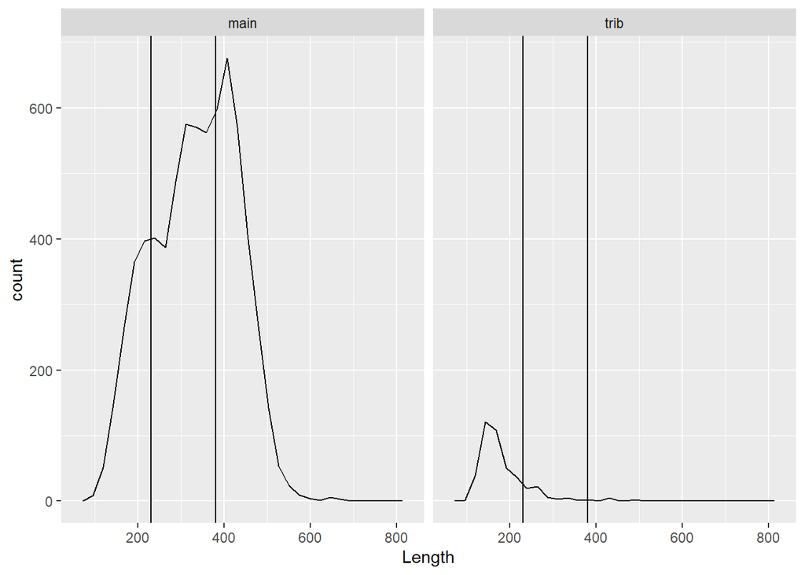

```r
ggplot(d %>% filter(species == "brown trout"), aes(Length)) +
  geom_freqpoly() +
  geom_vline(xintercept = c(tar_read(target_sizeCutoff1), tar_read(target_sizeCutoff2))) +
  facet_grid(~mainTrib)
```

```r
# dTame <- d %>%
#             select(Latitude, Longitude, tag, dateTime, species, Length, Weight) %>%
#             filter(tag != "", tag != "ad")
#
# write.csv(dTame, './dataOut/dTame.csv', row.names = FALSE)
```

### 0.4 Encounter histories

This is the data structure for the capture-recapture models. Each column is a sampling ‘occasion’ (here = month) and each row is an individual, where a ‘1’ indicates capture and a ‘0’ indicates not captured.

```r
str(eh$eh)
```

```
#>  num [1:5062, 1:24] 1 1 1 1 1 1 1 1 1 1 ...
#>  - attr(*, "dimnames")=List of 2
#>   ..$ : NULL
#>   ..$ : chr [1:24] "date_2018-05" "date_2018-06" "date_2018-07" "date_2018-08" ...
```

```r
kable(head(eh$eh,8))
```

| date_2018-05 | date_2018-06 | date_2018-07 | date_2018-08 | date_2018-09 | date_2018-10 | date_2019-04 | date_2019-05 | date_2019-06 | date_2019-07 | date_2019-08 | date_2019-09 | date_2019-10 | date_2020-07 | date_2020-08 | date_2020-09 | date_2020-10 | date_2021-04 | date_2021-05 | date_2021-06 | date_2021-07 | date_2021-08 | date_2021-09 | date_2021-10 |
| --- | --- | --- | --- | --- | --- | --- | --- | --- | --- | --- | --- | --- | --- | --- | --- | --- | --- | --- | --- | --- | --- | --- | --- |
| 1 | 0 | 0 | 0 | 0 | 0 | 0 | 0 | 0 | 0 | 0 | 0 | 0 | 0 | 0 | 0 | 0 | 0 | 0 | 0 | 0 | 0 | 0 | 0 |
| 1 | 0 | 0 | 0 | 0 | 0 | 0 | 0 | 0 | 0 | 0 | 0 | 0 | 0 | 0 | 0 | 0 | 0 | 0 | 0 | 0 | 0 | 0 | 0 |
| 1 | 1 | 0 | 0 | 0 | 0 | 0 | 0 | 0 | 0 | 0 | 0 | 0 | 0 | 0 | 0 | 0 | 0 | 0 | 0 | 0 | 0 | 0 | 0 |
| 1 | 0 | 0 | 0 | 0 | 0 | 0 | 0 | 0 | 0 | 0 | 0 | 0 | 0 | 0 | 0 | 0 | 0 | 0 | 0 | 0 | 0 | 0 | 0 |
| 1 | 0 | 0 | 0 | 0 | 0 | 0 | 0 | 0 | 0 | 0 | 0 | 0 | 0 | 0 | 1 | 0 | 0 | 0 | 0 | 0 | 1 | 0 | 0 |
| 1 | 0 | 0 | 0 | 0 | 0 | 0 | 0 | 0 | 0 | 0 | 0 | 0 | 0 | 0 | 0 | 0 | 0 | 0 | 0 | 0 | 0 | 0 | 0 |
| 1 | 1 | 0 | 0 | 0 | 0 | 1 | 0 | 0 | 0 | 0 | 0 | 0 | 0 | 0 | 0 | 0 | 0 | 0 | 0 | 0 | 0 | 0 | 0 |
| 1 | 0 | 0 | 0 | 0 | 0 | 0 | 0 | 0 | 0 | 0 | 0 | 0 | 0 | 0 | 0 | 0 | 0 | 0 | 0 | 0 | 0 | 0 | 0 |

```r
table(paste(eh$first, eh$last, sep="_"))
```

```
#>
#>  1_24 10_24 11_24 12_24 13_24 14_24 15_24 16_24 17_24 18_24 19_24  2_24 20_24
#>   173   359   295   264   257   296   244   291   382   185   120   263   181
#> 21_24 22_24 23_24  3_24  4_24  5_24  6_24  7_24  8_24  9_24
#>    82   288   157   373     8    62   231   233   130   188
```

There are very few transitions between main and trib and we can characterize size transitions better with a growth model - run phiT_pT_psiT models separately for main and trib

```r
s <- eh$stateMatrix
s[s == 0] <- NA

s2 <- data.frame(s) %>%
  unite("all", sep = "", na.rm = TRUE, remove = TRUE) %>%
  #distinct() %>%
  arrange()

table(s2)
```

```
#> all
#>          1         11        111       1112        112       1122      11222
#>        964         66          4          1          6          3          1
#>      11223         12        122       1222    1222222     122233    1223333
#>          1         44         21          5          1          1          1
#>        123         13      13233          2         22        222       2221
#>          1          4          1       1645        286         81          1
#>       2222      22222     222222    2222222     222223     222233       2223
#>         33          8          2          2          1          1          7
#>      22233     222333        223       2232       2233      22333     223333
#>          7          2         35          1         15          5          2
#>    2233333   22333333         23        233       2333      23333     233333
#>          3          2         74         39         11          5          3
#>       2533          3         32         33        333       3333      33333
#>          1       1022          2        189         83         35         24
#>     333333    3333333   33333333  333333333 3333333333          4         42
#>         12          4          4          2          1        182          1
#>         44        444       4444   44444455    4444455      44445    4444555
#>         47         12          3          1          1          1          1
#>       4445       4455         45        455       4555          5       5455
#>          1          2          2          1          3         17          1
#>         55        555        556          6         63
#>          1          2          1          6          1
```

Summary info for years and occasions

```r
years <- colnames(eh$eh) %>%
  substr(6,9) %>%
  as.numeric()

months <- colnames(eh$eh) %>%
  substr(11,12) %>%
  as.numeric()

occs <- colnames(eh$eh)
```

## 1 Models

‘phi’ = apparent survival (probability of staying in the area = p(survival) + p(not moving out of area)).  
‘p’ = probability of capture given that the fish is alive. ‘psi’ = probability of transitioning from one state to another. Here, states are size bins.

### 1.1 phiT_pT_psiT_main

Load data ‘main’ for analysis

```r
#d_tt <- tar_read(target_d_trib)
eh_main <- tar_read(target_eh_main)

str(eh_main$eh)
```

```
#>  num [1:4777, 1:23] 1 1 1 1 1 1 1 1 1 1 ...
#>  - attr(*, "dimnames")=List of 2
#>   ..$ : NULL
#>   ..$ : chr [1:23] "date_2018-05" "date_2018-06" "date_2018-07" "date_2018-09" ...
```

```r
#kable(eh_main$eh[1:8,1:10])

table(paste(eh_main$first, eh_main$last, sep="_"))
```

```
#>
#>  1_23 10_23 11_23 12_23 13_23 14_23 15_23 16_23 17_23 18_23 19_23  2_23 20_23
#>   173   242   244   238   296   244   291   382   185   120   181   263    82
#> 21_23 22_23  3_23  4_23  5_23  6_23  7_23  8_23  9_23
#>   288   157   313    51   216   233   130   188   260
```

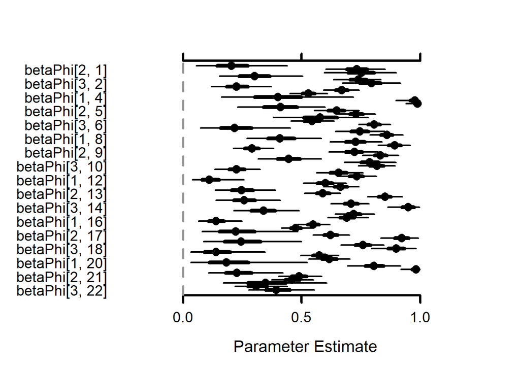

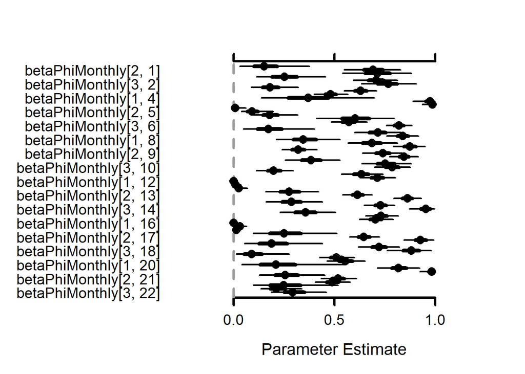

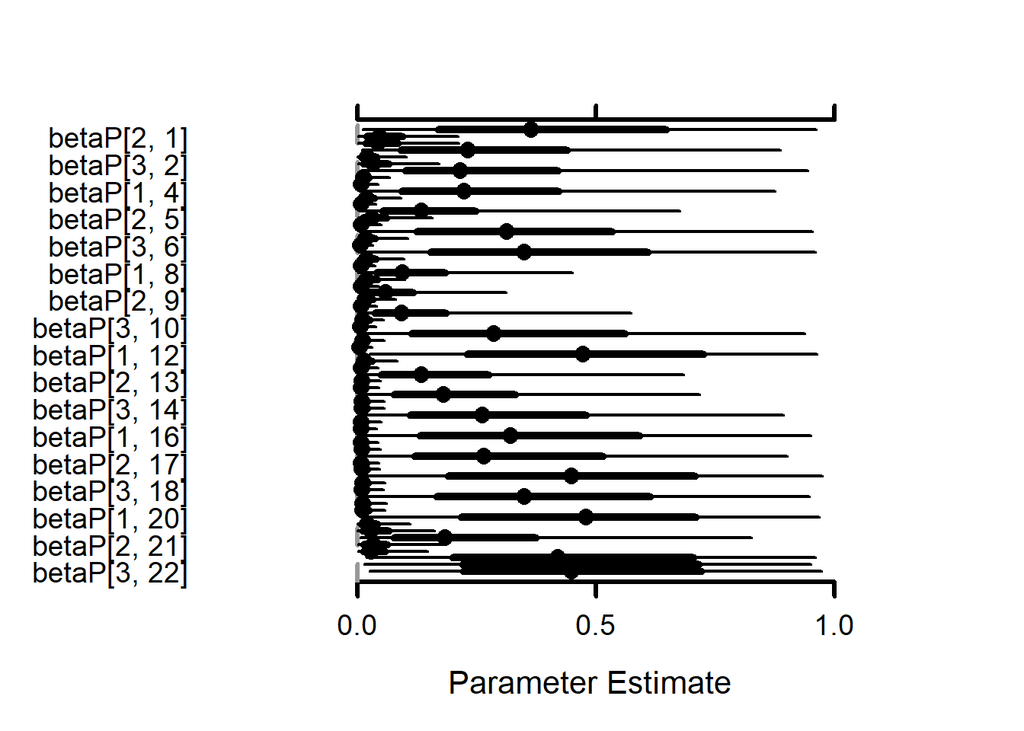

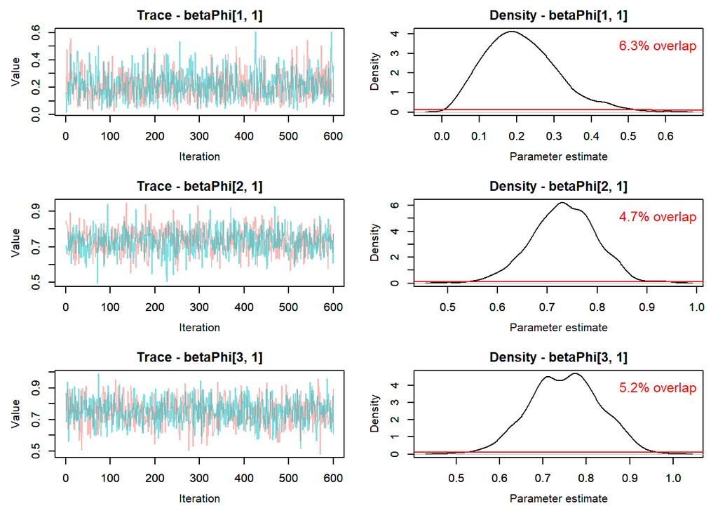

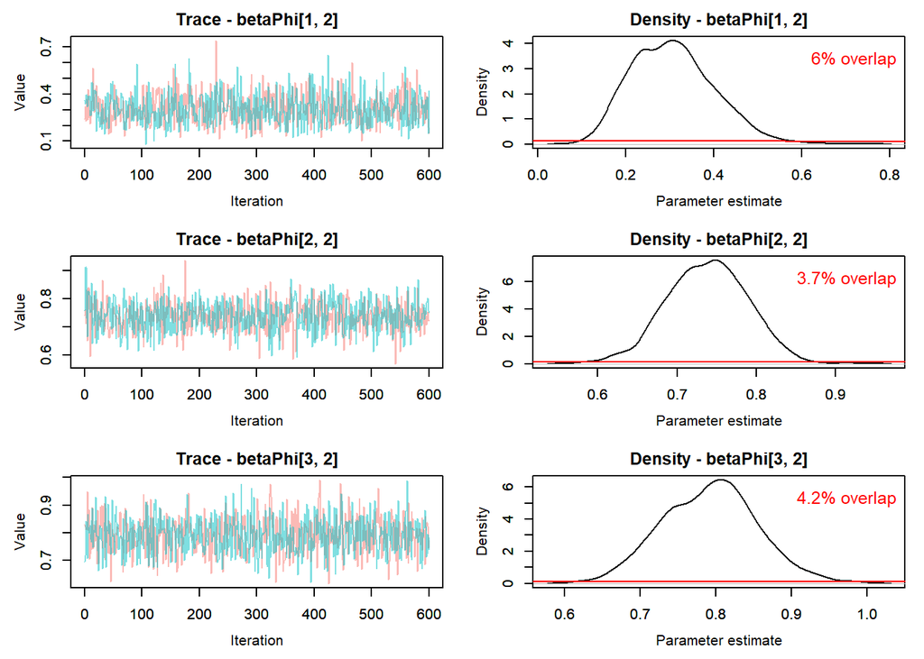

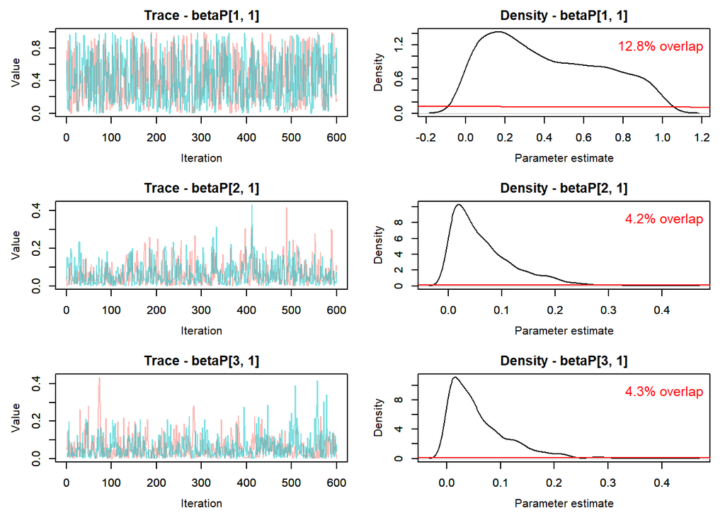

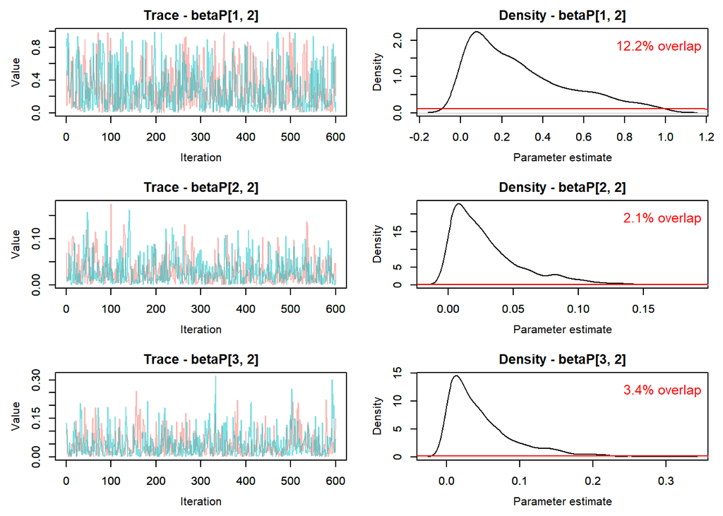

```r
### Read the model run into global memory
if (tar_exist_objects(c("tt_modelOut_main"))) {
  mod_tt_main <- tar_read(tt_modelOut_main)

  MCMCplot(object = mod_tt_main$mcmc, params = "betaPhi")
  MCMCplot(object = mod_tt_main$mcmc, params = "betaPhiMonthly")
  MCMCplot(object = mod_tt_main$mcmc, params = "betaP")

   priors <- rnorm(tar_read(tt_runData_main)$nIter * tar_read(tt_runData_main)$nChains, 0, 1/sqrt(.1))
   MCMCtrace(object = mod_tt_main$mcmc,
             ISB = FALSE,
             exact = TRUE,
             params = c("betaPhi[1, 1]", "betaPhi[2, 1]", "betaPhi[3, 1]",
                        "betaPhi[1, 2]", "betaPhi[2, 2]", "betaPhi[3, 2]"
                        #"betaPhi[1, 3]", "betaPhi[2, 3]", "betaPhi[3, 3]"
                        ),
             pdf = FALSE,
             priors = priors
             )

      MCMCtrace(object = mod_tt_main$mcmc,
             ISB = FALSE,
             exact = TRUE,
             params = c("betaP[1, 1]", "betaP[2, 1]", "betaP[3, 1]",
                        "betaP[1, 2]", "betaP[2, 2]", "betaP[3, 2]"
                        #"betaP[1, 3]", "betaP[2, 3]", "betaP[3, 3]"
                        ),
             pdf = FALSE,
             priors = priors
             )

    modSummary_tt_main <- MCMCsummary(object = mod_tt_main$mcmc, round = 3) %>%
      rename(lo = '2.5%', med = '50%', hi = '97.5%')
}
```

### 1.2 Main, phi, p and psi

```r
  nS <- mod_tt_main$myConstants$nStates
  nT <- mod_tt_main$myConstants$T

  phi_tt_main <- modSummary_tt_main %>%
    filter(substr(row.names(modSummary_tt_main), 1, 8) == "betaPhi[") %>%
    add_column(data.frame(state = 1:nS, dateYM = rep(1:(nT - 1), each = nS))) %>%
    mutate(year = years[dateYM],
           month = months[dateYM],
           river = "main")

  phiMonthly_tt_main <- modSummary_tt_main %>%
    filter(substr(row.names(modSummary_tt_main), 1, 8) == "betaPhiM") %>%
    add_column(data.frame(state = 1:nS, dateYM = rep(1:(nT - 1), each = nS))) %>%
    mutate(year = years[dateYM],
           month = months[dateYM],
           river = "main")

  p_tt_main <- modSummary_tt_main %>%
    filter(substr(row.names(modSummary_tt_main), 1, 6) == "betaP[") %>%
    add_column(data.frame(state = 1:nS, dateYM = rep(1:(nT - 1), each = nS))) %>%
    mutate(year = years[dateYM],
           month = months[dateYM],
           river = "main")

  psi_tt_main <- modSummary_tt_main %>%
    filter(substr(row.names(modSummary_tt_main), 1, 3) == "psi") %>%
    add_column(data.frame(stateFrom = 1:nS, stateTo = rep(1:nS, each = nS), dateYM = rep(1:(nT - 1), each = nS*nS))) %>%
    mutate(year = years[dateYM],
           month = months[dateYM],
           river = "main")
```

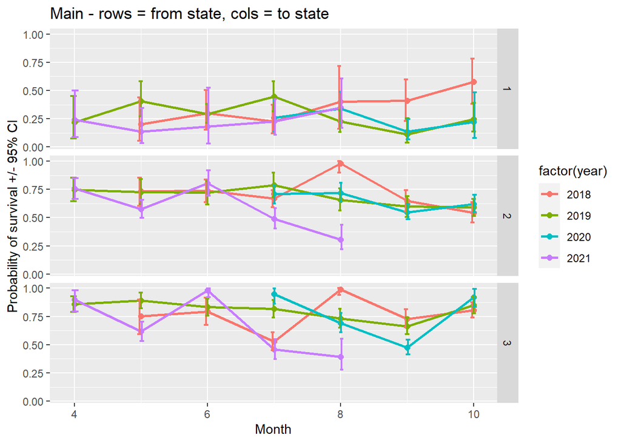

```r
#phi
ggplot(phi_tt_main, aes(month, med, color = factor(year))) +
  geom_point(size = 2) +
  geom_line(size = 1) +
  geom_errorbar(aes(ymin = lo, ymax = hi),
                width = 0.2,
                position = position_dodge(0.05),
                size = 0.75) +
  ylab("Probability of survival +/- 95% CI") +
  xlab("Month") +
  ggtitle("Main - rows = from state, cols = to state") +
  facet_grid(rows = vars(state))
```

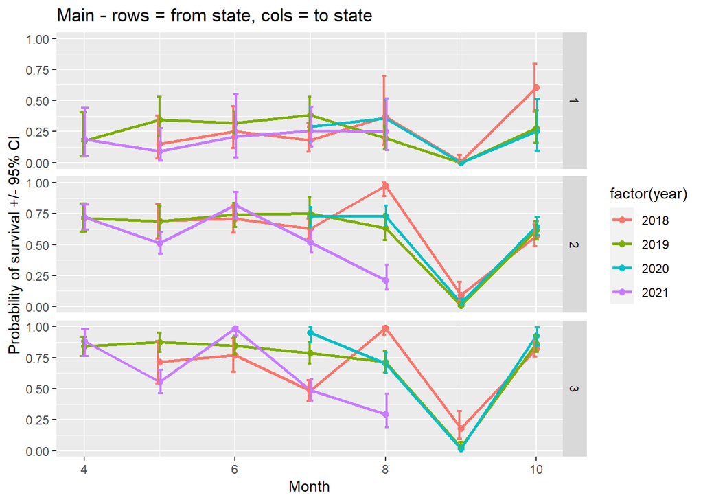

```r
#phiMonthly
ggplot(phiMonthly_tt_main, aes(month, med, color = factor(year))) +
  geom_point(size = 2) +
  geom_line(size = 1) +
  geom_errorbar(aes(ymin = lo, ymax = hi),
                width = 0.2,
                position = position_dodge(0.05),
                size = 0.75) +
  ylab("Probability of survival +/- 95% CI") +
  xlab("Month") +
  ggtitle("Main - rows = from state, cols = to state") +
  facet_grid(rows = vars(state))
```

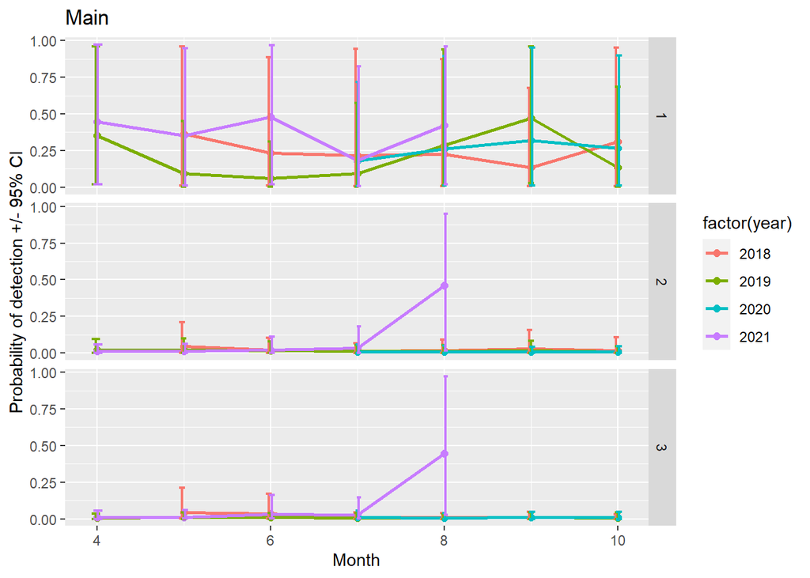

```r
# p
ggplot(p_tt_main, aes(month, med, color = factor(year))) +
  geom_point(size = 2) +
  geom_line(size = 1) +
  geom_errorbar(aes(ymin = lo, ymax = hi),
                width = 0.2,
                position = position_dodge(0.05),
                size = 0.75) +
  ylab("Probability of detection +/- 95% CI") +
  xlab("Month") +
  ggtitle("Main") +
  facet_grid(rows = vars(state))
```

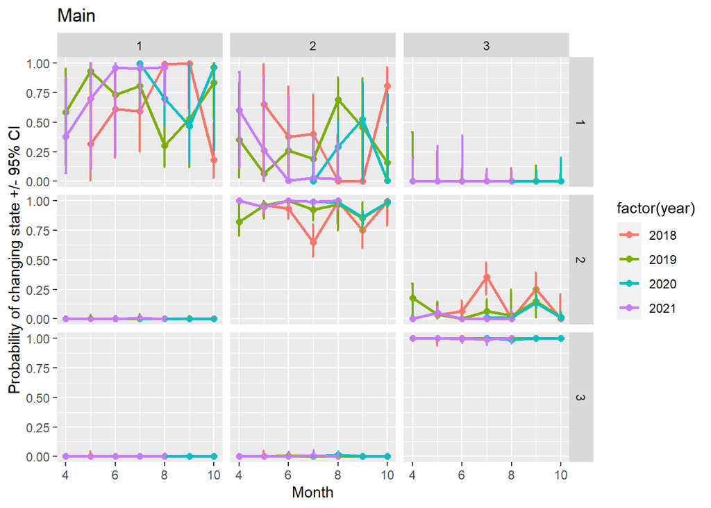

```r
#psi
ggplot(psi_tt_main, aes(month, med, color = factor(year))) +
  geom_point(size = 2) +
  geom_line(size = 1) +
  geom_errorbar(aes(ymin = lo, ymax = hi),
              width = 0.2,
              position = position_dodge(0.03),
              size = 0.75) +
  ylab("Probability of changing state +/- 95% CI") +
  xlab("Month") +
  ggtitle("Main") +
  facet_grid(rows = vars(stateFrom),
             cols = vars(stateTo))
```

Compare phi and phiMonthly

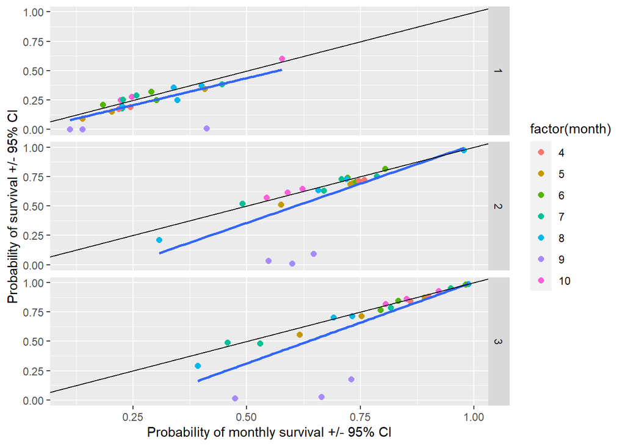

```r
phiBoth_tt_main <- add_column(phi_tt_main, phiMonthly_tt_main)

ggplot(phiBoth_tt_main, aes(med, med.1)) +
  geom_point(aes( color = factor(month)), size = 2) +
  geom_smooth(method = "lm", se = FALSE) +
  geom_abline(intercept = 0, slope = 1) +
  # geom_line(size = 1) +
  # geom_errorbar(aes(ymin = lo, ymax = hi),
  #               width = 0.2,
  #               position = position_dodge(0.05),
  #               size = 0.75) +
  ylab("Probability of survival +/- 95% CI") +
  xlab("Probability of monthly survival +/- 95% CI") +
  #ggtitle("Main - rows = from state, cols = to state") +
  facet_grid(rows = vars(state))
```

## 2 phiT_pT_psiT_trib

Load data ‘trib’ for analysis

```r
#d_tt <- tar_read(target_d_trib)
eh_trib <- tar_read(target_eh_trib)

str(eh_trib$eh)
```

```
#>  num [1:288, 1:14] 1 1 1 1 1 1 1 1 1 1 ...
#>  - attr(*, "dimnames")=List of 2
#>   ..$ : NULL
#>   ..$ : chr [1:14] "date_2018-07" "date_2018-08" "date_2018-09" "date_2018-10" ...
```

```r
#kable(eh_trib$eh[1:8,1:10])

table(paste(eh_trib$first, eh_trib$last, sep="_"))
```

```
#>
#> 1_14 2_14 3_14 4_14 5_14 6_14 7_14 8_14
#>   60    8   12   15  100   53   20   20
```

Plot trib model estimates

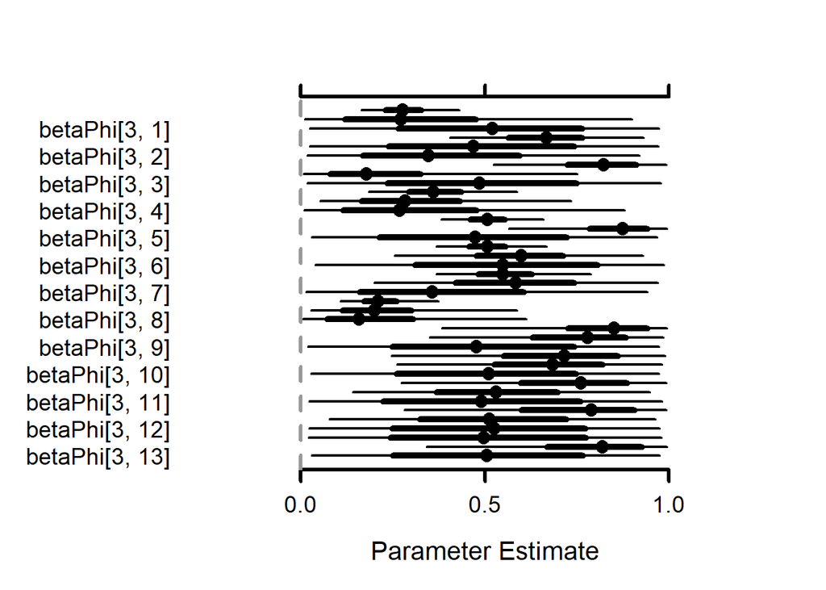

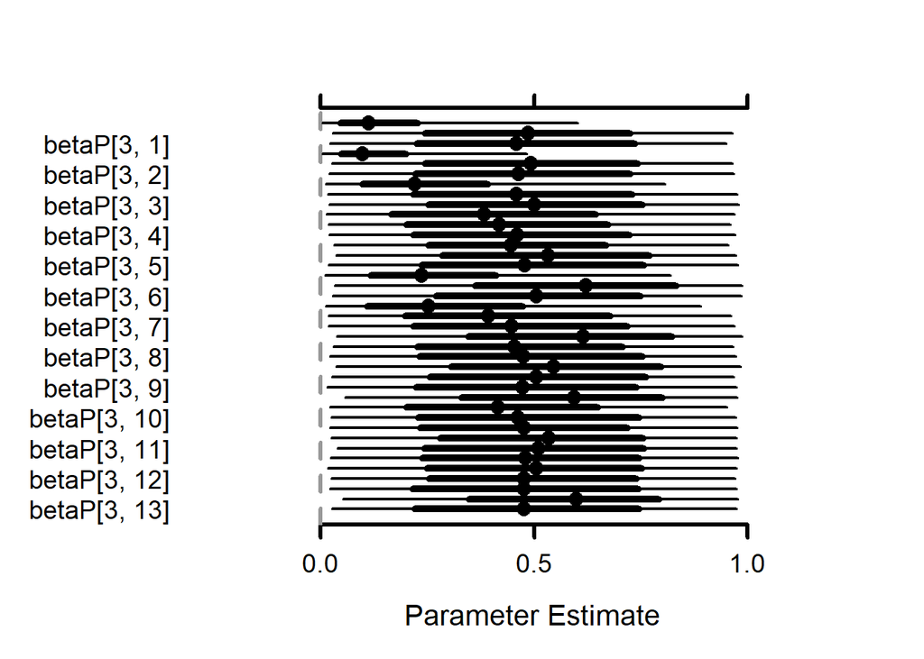

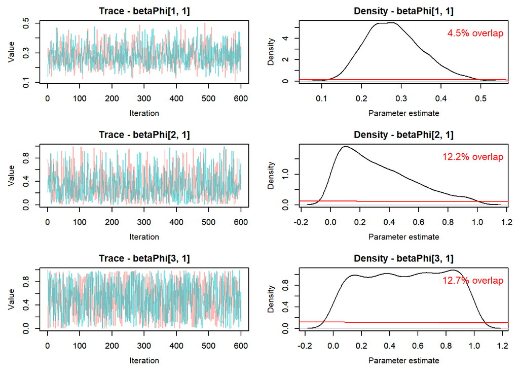

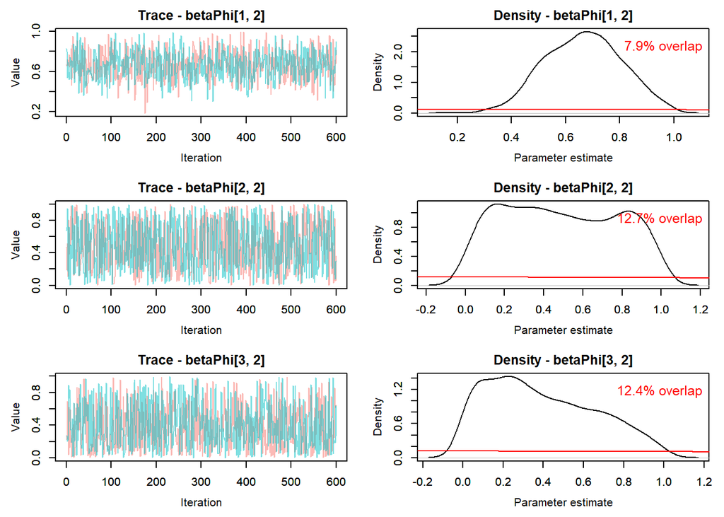

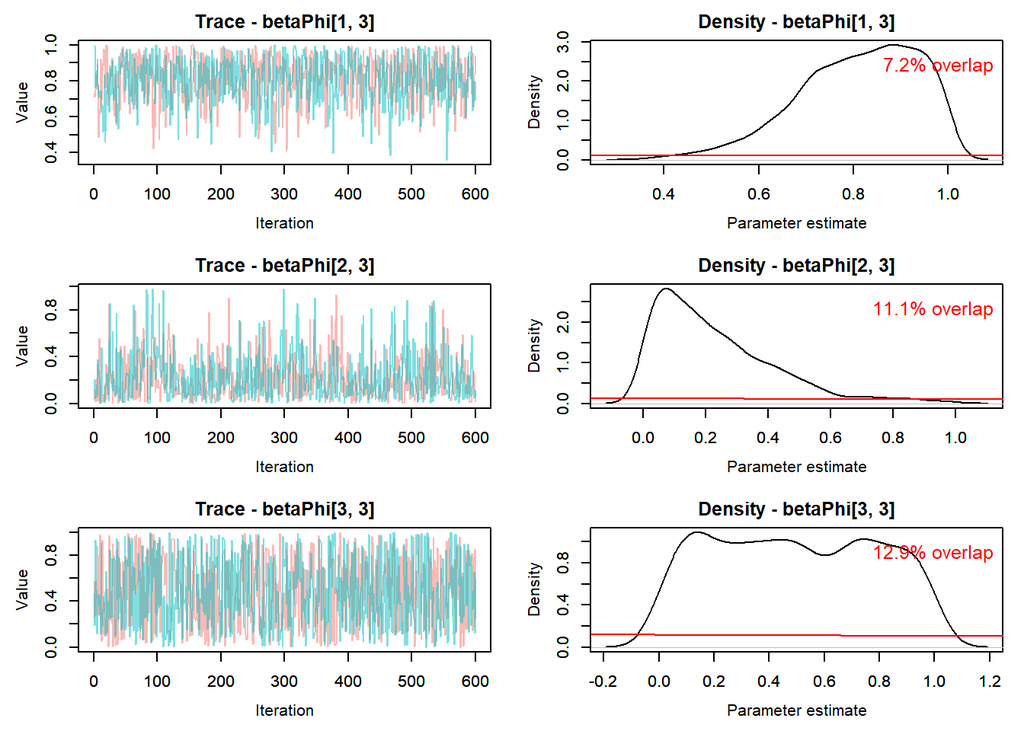

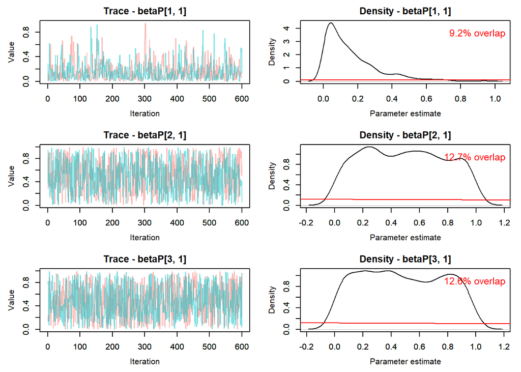

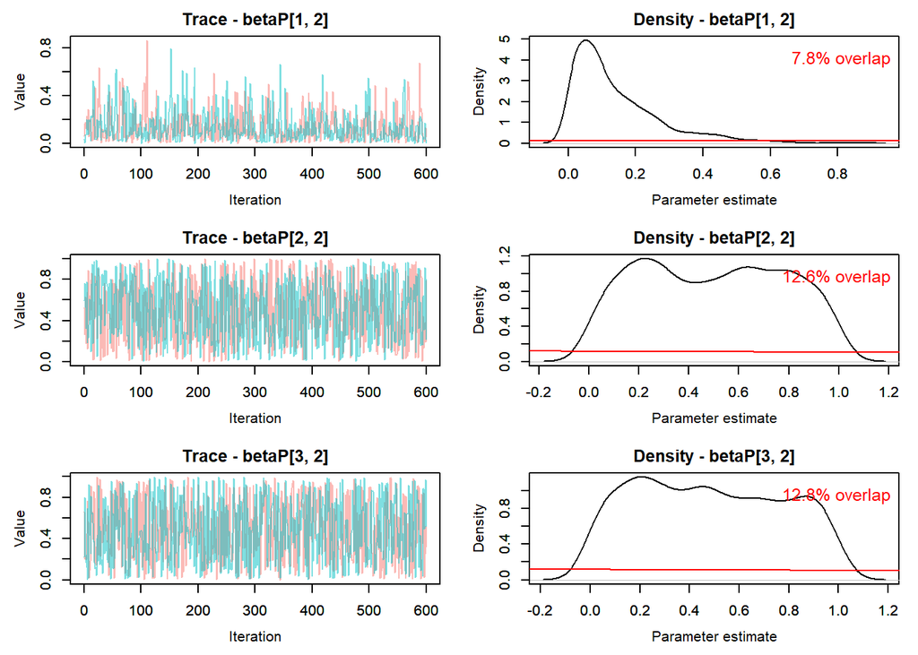

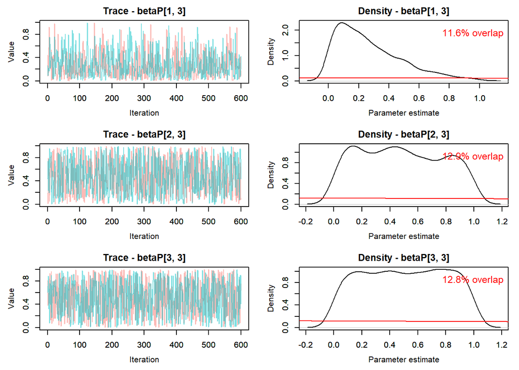

```r
### Read the model run into global memory
if (tar_exist_objects(c("tt_modelOut_trib"))) {
  mod_tt_trib <- tar_read(tt_modelOut_trib)

  MCMCplot(object = mod_tt_trib$mcmc, params = "betaPhi")
  #MCMCplot(object = mod_tt_trib$mcmc, params = "betaPhiMonthly")
  MCMCplot(object = mod_tt_trib$mcmc, params = "betaP")

   MCMCtrace(object = mod_tt_trib$mcmc,
             ISB = FALSE,
             exact = TRUE,
             params = c("betaPhi[1, 1]", "betaPhi[2, 1]", "betaPhi[3, 1]",
                        "betaPhi[1, 2]", "betaPhi[2, 2]", "betaPhi[3, 2]",
                        "betaPhi[1, 3]", "betaPhi[2, 3]", "betaPhi[3, 3]"),
             pdf = FALSE,
             priors = priors
             )

    MCMCtrace(object = mod_tt_trib$mcmc,
           ISB = FALSE,
           exact = TRUE,
           params = c("betaP[1, 1]", "betaP[2, 1]", "betaP[3, 1]",
                      "betaP[1, 2]", "betaP[2, 2]", "betaP[3, 2]",
                      "betaP[1, 3]", "betaP[2, 3]", "betaP[3, 3]"),
           pdf = FALSE,
           priors = priors
           )

    modSummary_tt_trib <- MCMCsummary(object = mod_tt_trib$mcmc, round = 3) %>%
      rename(lo = '2.5%', med = '50%', hi = '97.5%')
}
```

```r
  nS <- mod_tt_trib$myConstants$nStates
  nT <- mod_tt_trib$myConstants$T

  phi_tt_trib <- modSummary_tt_trib %>%
    filter(substr(row.names(modSummary_tt_trib), 1, 7) == "betaPhi") %>%
    add_column(data.frame(state = 1:nS, dateYM = rep(1:(nT - 1), each = nS))) %>%
    mutate(year = years[dateYM],
           month = months[dateYM],
           river = "trib")

  p_tt_trib <- modSummary_tt_trib %>%
    filter(substr(row.names(modSummary_tt_trib), 1, 6) == "betaP[") %>%
    add_column(data.frame(state = 1:nS, dateYM = rep(1:(nT - 1), each = nS))) %>%
    mutate(year = years[dateYM],
           month = months[dateYM],
           river = "trib")

  psi_tt_trib <- modSummary_tt_trib %>%
    filter(substr(row.names(modSummary_tt_trib), 1, 3) == "psi") %>%
    add_column(data.frame(stateFrom = 1:nS, stateTo = rep(1:nS, each = nS), dateYM = rep(1:(nT - 1), each = nS*nS))) %>%
    mutate(year = years[dateYM],
           month = months[dateYM],
           river = "trib")
```

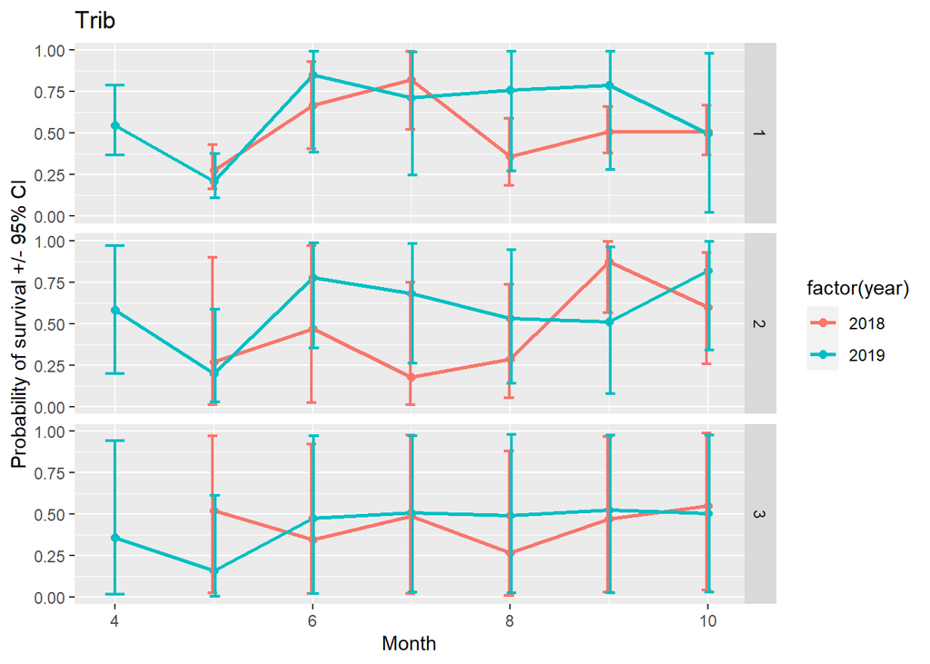

```r
#phi
ggplot(phi_tt_trib, aes(month, med, color = factor(year))) +
  geom_point(size = 2) +
  geom_line(size = 1) +
  geom_errorbar(aes(ymin = lo, ymax = hi),
                width = 0.2,
                position = position_dodge(0.05),
                size = 0.75) +
  ylab("Probability of survival +/- 95% CI") +
  xlab("Month") +
  ggtitle("Trib") +
  facet_grid(rows = vars(state))
```

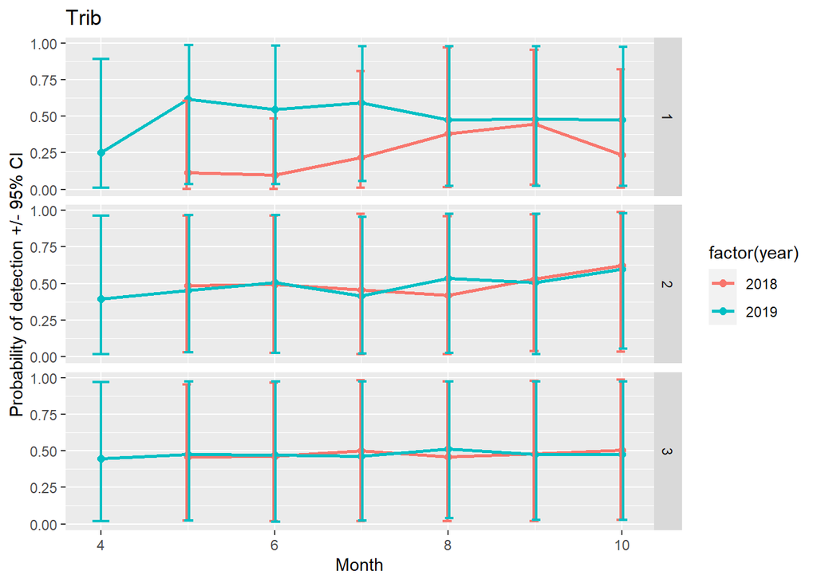

```r
# p
ggplot(p_tt_trib, aes(month, med, color = factor(year))) +
  geom_point(size = 2) +
  geom_line(size = 1) +
  geom_errorbar(aes(ymin = lo, ymax = hi),
                width = 0.2,
                position = position_dodge(0.05),
                size = 0.75) +
  ylab("Probability of detection +/- 95% CI") +
  xlab("Month") +
  ggtitle("Trib") +
  facet_grid(rows = vars(state))
```

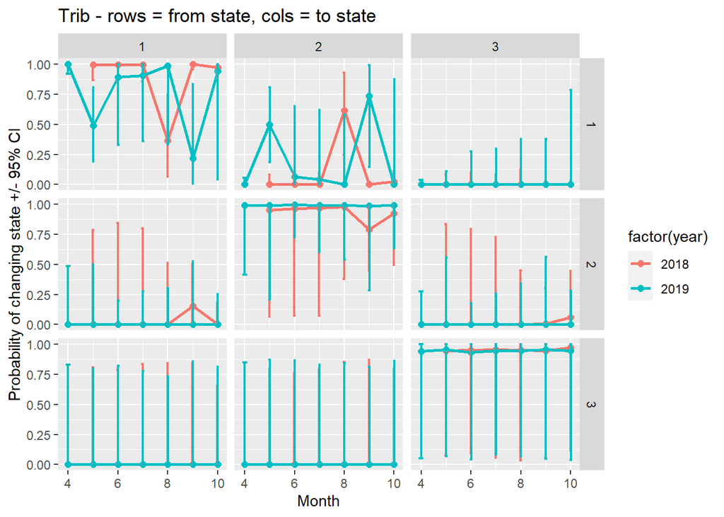

```r
#psi
ggplot(psi_tt_trib, aes(month, med, color = factor(year))) +
  geom_point(size = 2) +
  geom_line(size = 1) +
  geom_errorbar(aes(ymin = lo, ymax = hi),
              width = 0.2,
              position = position_dodge(0.03),
              size = 0.75) +
  ylab("Probability of changing state +/- 95% CI") +
  xlab("Month") +
  ggtitle("Trib - rows = from state, cols = to state") +
  facet_grid(rows = vars(stateFrom),
             cols = vars(stateTo))
```

## 3 Combine main and trib estimates

```r
phi_tt_mainTrib <- add_row(phi_tt_main, phi_tt_trib)
psi_tt_mainTrib <- add_row(psi_tt_main, psi_tt_trib)
```

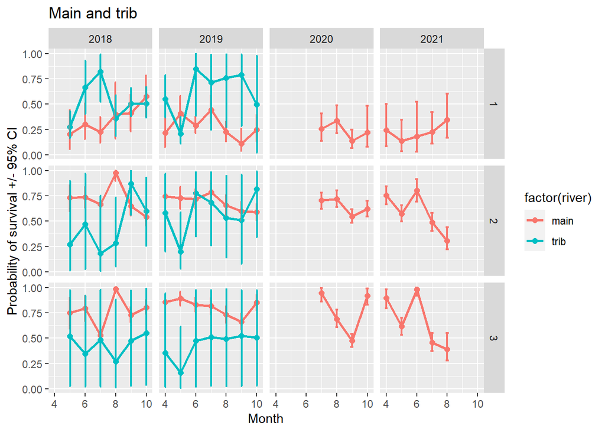

```r
ggplot(phi_tt_mainTrib, aes(month, med, color = factor(river))) +
  geom_point(size = 2) +
  geom_line(size = 1) +
  geom_errorbar(aes(ymin = lo, ymax = hi),
                width = 0.2,
                position = position_dodge(0.05),
                size = 0.75) +
  ylab("Probability of survival +/- 95% CI") +
  xlab("Month") +
  ggtitle("Main and trib") +
  facet_grid(rows = vars(state),
             cols = vars(year))
```

## 4 Calculate means for broad comparisons

```r
  # Overall means across occasions
# Main
  (
    phi_tt_main_means <- phi_tt_main %>%
    group_by(state) %>%
    summarise(meanPhi = mean(mean),
              sdPhi = sd(mean),
              meanLo = mean(lo),
              meanMed = mean(med),
              meanHi = mean(hi)) %>%
    mutate(river = "main") %>%
    ungroup()
  )
```

```
#> # A tibble: 3 × 7
#>   state meanPhi sdPhi meanLo meanMed meanHi river
#>   <int>   <dbl> <dbl>  <dbl>   <dbl>  <dbl> <chr>
#> 1     1   0.287 0.112  0.145   0.280  0.473 main
#> 2     2   0.667 0.132  0.575   0.667  0.759 main
#> 3     3   0.756 0.171  0.673   0.756  0.836 main
```

```r
  (
    psi_tt_main_means <- psi_tt_main %>%
    group_by(stateFrom, stateTo) %>%
    summarise(meanPhi = mean(mean),
              sdPhi = sd(mean),
              meanLo = mean(lo),
              meanMed = mean(med),
              meanHi = mean(hi)) %>%
    mutate(river = "main") %>%
    ungroup()
    )
```

```
#> # A tibble: 9 × 8
#>   stateFrom stateTo meanPhi    sdPhi    meanLo   meanMed  meanHi river
#>       <int>   <int>   <dbl>    <dbl>     <dbl>     <dbl>   <dbl> <chr>
#> 1         1       1 0.687   0.226    0.349     0.705     0.931   main
#> 2         1       2 0.298   0.225    0.0653    0.280     0.637   main
#> 3         1       3 0.0147  0.0128   0         0.0000455 0.135   main
#> 4         2       1 0.00232 0.00186  0         0.000227  0.0169  main
#> 5         2       2 0.928   0.0901   0.845     0.935     0.977   main
#> 6         2       3 0.0702  0.0904   0.0222    0.0634    0.152   main
#> 7         3       1 0.00109 0.000750 0         0         0.00968 main
#> 8         3       2 0.003   0.00405  0.0000909 0.00105   0.0175  main
#> 9         3       3 0.996   0.00420  0.978     0.999     1.00    main
```

```r
# Trib
  (
    phi_tt_trib_means <- phi_tt_trib %>%
    group_by(state) %>%
    summarise(meanPhi = mean(mean),
              sdPhi = sd(mean),
              meanLo = mean(lo),
              meanMed = mean(med),
              meanHi = mean(hi)) %>%
    mutate(river = "trib") %>%
    ungroup()
    )
```

```
#> # A tibble: 3 × 7
#>   state meanPhi  sdPhi meanLo meanMed meanHi river
#>   <int>   <dbl>  <dbl>  <dbl>   <dbl>  <dbl> <chr>
#> 1     1   0.568 0.194  0.286    0.578  0.798 trib
#> 2     2   0.526 0.206  0.179    0.522  0.901 trib
#> 3     3   0.449 0.0964 0.0222   0.436  0.933 trib
```

```r
  (psi_tt_trib_means <- psi_tt_trib %>%
    group_by(stateFrom, stateTo) %>%
    summarise(meanPhi = mean(mean),
              sdPhi = sd(mean),
              meanLo = mean(lo),
              meanMed = mean(med),
              meanHi = mean(hi)) %>%
    mutate(river = "trib") %>%
    ungroup()
    )
```

```
#> # A tibble: 9 × 8
#>   stateFrom stateTo meanPhi  sdPhi   meanLo   meanMed meanHi river
#>       <int>   <int>   <dbl>  <dbl>    <dbl>     <dbl>  <dbl> <chr>
#> 1         1       1  0.799  0.252  0.512    0.828      0.953 trib
#> 2         1       2  0.178  0.247  0.0446   0.152      0.456 trib
#> 3         1       3  0.0225 0.0263 0        0.0000769  0.209 trib
#> 4         2       1  0.0631 0.0465 0.000692 0.0122     0.474 trib
#> 5         2       2  0.880  0.0653 0.380    0.963      0.999 trib
#> 6         2       3  0.0566 0.0319 0        0.00562    0.461 trib
#> 7         3       1  0.1    0.0111 0        0.00131    0.800 trib
#> 8         3       2  0.104  0.0104 0        0.00138    0.831 trib
#> 9         3       3  0.797  0.0177 0.0618   0.950      1     trib
```

## 5 Combine mean main and trib estimates

```r
phi_tt_mainTrib_means <- add_row(phi_tt_main_means, phi_tt_trib_means)
psi_tt_mainTrib_means <- add_row(psi_tt_main_means, psi_tt_trib_means)
```

Probability of survival for each size state

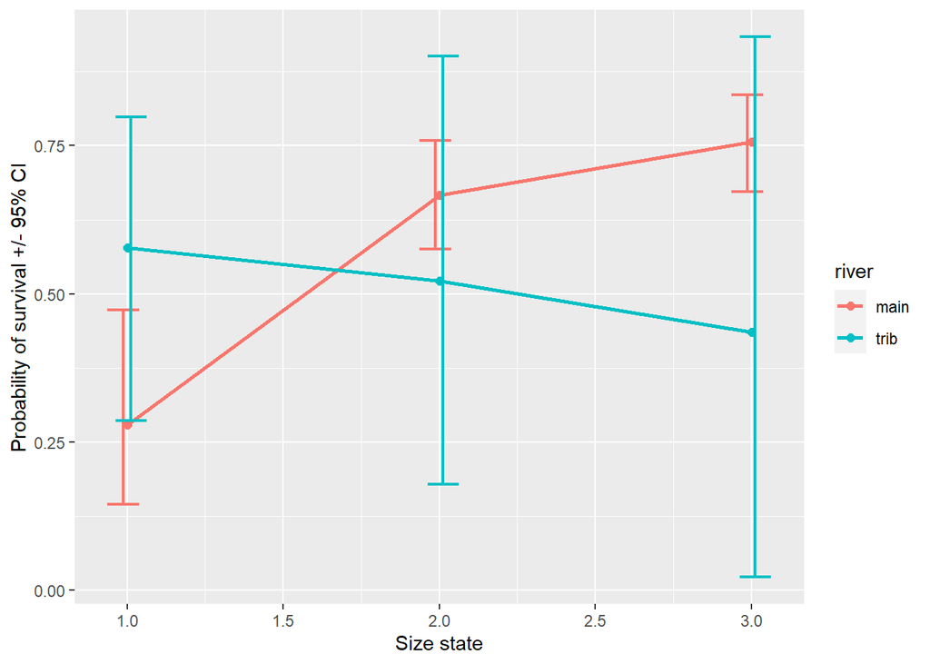

```r
ggplot(phi_tt_mainTrib_means, aes(state, meanMed, color = river)) +
  geom_point(size = 2) +
  geom_line(size = 1) +
  geom_errorbar(aes(ymin = meanLo, ymax = meanHi),
                width = 0.2,
                position = position_dodge(0.05),
                size = 0.75) +
  ylab("Probability of survival +/- 95% CI") +
  xlab("Size state")
```

Probability of changing state. ‘From’ size states are on the x-axis, ‘to’ size states are in the rows of the facets

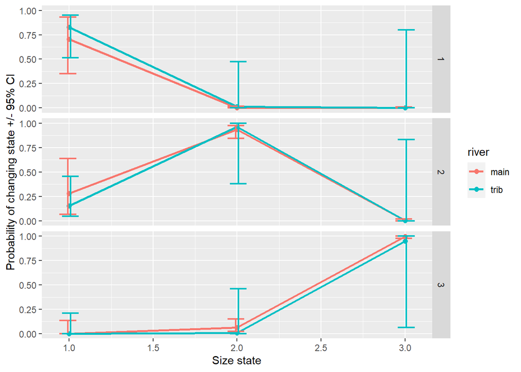

```r
ggplot(psi_tt_mainTrib_means, aes(stateFrom, meanMed, color = river)) +
  geom_point(size = 2) +
  geom_line(size = 1) +
  geom_errorbar(aes(ymin = meanLo, ymax = meanHi),
              width = 0.2,
              position = position_dodge(0.03),
              size = 0.75) +
  ylab("Probability of changing state +/- 95% CI") +
  xlab("Size state") +
  facet_grid(rows = vars(stateTo))
```

Matrix model

```r
# mMain <- matrix(
#   c()
# )
```

## 6 phiT_pT_psiT_mainTrib

Main and trib modeled together. Not using this as of 7-27-22.

```r
### Read the model run into global memory
# if (tar_exist_objects(c("ttt_modelOut"))) {
#   mod_ttt <- tar_read(ttt_modelOut)
#
#   #MCMCplot(object = mod$mcmc)
#
#   modSummary_ttt <- MCMCsummary(object = mod_ttt$mcmc, round = 3)
# }
#kable(modSummary %>%
#        add_column(data.frame(year = rep(years[1:15], 2), dateYM = rep(occs[1:15], 2)) )


#  d %>%
#  summarize(unique(data.frame(dateYM, occ)))
```

```r
# nS <- tar_read(ttt_nStates)
# nT <- tar_read(ttt_myConstants)$T
#
# modSummaryPhi_ttt <- modSummary_ttt %>%
#   filter(substr(row.names(modSummary), 1, 10) == "betaPhiOut") %>%
#   add_column(data.frame(state = 1:nS, dateYM = rep(1:(nT - 1), each = nS))) %>%
#   mutate(mainTrib = ifelse(state < 4, "Main", "Trib"),
#          size = paste0("Size", (state - 1) %% 3 + 1))
#
# ggplot(modSummaryPhi_ttt, aes(dateYM, mean)) +
#   geom_point() +
#   geom_line() +
#   facet_grid(mainTrib ~ size)
#
#
# # modSummaryYears <- modSummary %>%
# #   filter(substr(row.names(modSummary), 1, 3) == "betaPhiout") %>%
# #   add_column(data.frame(year = years[1:15], dateYM = occs[1:15], occ = 1:15)) %>%
# #   group_by(year) %>%
# #   mutate(maxSampPerYear = occ == max(occ))
# #
# # kable(
# #   modSummaryYears %>%
# #   group_by(year) %>%
# #   filter(!maxSampPerYear) %>%
# #   summarize(phiProd = prod(mean),
# #             dateRange = range(dateYM)) %>%
# #     as.data.frame()
# # )
#   MCMCplot(object = mod$mcmc, params = "betaPhiRiverOut")
#
#   priors <- rnorm(tar_read(ttt_runData)$nIter * tar_read(ttt_runData)$nChains, 0, 1/sqrt(.1))
#   MCMCtrace(object = mod$mcmc,
#             #ISB = FALSE,
#             #exact = TRUE,
#             params = c("betaPhiRiverOut"),
#             pdf = FALSE,
#             priors = priors
#             )
#
#     MCMCtrace(object = mod$mcmc,
#             #ISB = FALSE,
#             #exact = TRUE,
#             params = c("betaPhiOut"),
#             pdf = FALSE,
#             priors = priors
#             )
```

```r
#create data frame for summarizing p results

# modSummaryYearsP <- modSummary %>%
#   filter(substr(row.names(modSummary), 1, 2) == "p[") %>%
#   add_column(data.frame(year = years[1:15], dateYM = occs[1:15], occ = 1:15)) %>%
#   group_by(year) %>%
#   mutate(maxSampPerYear = occ == max(occ))
#
# kable(
#   modSummaryYearsP %>%
#   group_by(year) %>%
#   summarize(pMean = mean(mean),
#             dateRange = range(dateYM))
#   )
```

```r
# # modSummaryYearsP <- modSummary %>%
# #   filter(substr(row.names(modSummary), 1, 2) == "p[") %>%
# #   add_column(data.frame(year = years[1:15], dateYM = occs[1:15], occ = 1:15)) %>%
# #   group_by(year) %>%
# #   mutate(maxSampPerYear = occ == max(occ))
#
# modSummaryPsi_ttt <- modSummary_ttt %>%
#   filter(substr(row.names(modSummary_ttt), 1, 3) == "psi") %>%
#   add_column(data.frame(state = 1:nS, state2 = rep(1:nS, each = nS), dateYM = rep(1:(nT - 1), each = nS * nS))) %>%
#   mutate(mainTrib = ifelse(state < 4, "Main", "Trib"),
#          size = paste0("Size", (state - 1) %% 3 + 1))
#
# ggplot(modSummaryPsi_ttt, aes(dateYM, mean, color = factor(state2))) +
#   geom_point() +
#   facet_grid(mainTrib ~ size)
#
```